# Variational Beltrami Regularization of Velocity Fields in Diffeomorphic Registration

Pullback Metric Geometry, Levi-Civita Transport, Euler–Lagrange Divergence Operators, and Continuum Trade-Offs

Author

ANTsX / syntx Computational Anatomy Monograph

Published

November 12, 2026

**TipMethodological Contract & Figure Provenance**

*(To build a slide deck from the same source, run `quarto render beltrami_velocity_regularization.qmd --to revealjs`.)*

# 1 The Physical Problem — Why Regularize a Velocity Field?

## 1.1 Variational & Kinematic Formulation

Large Deformation Diffeomorphic Metric Mapping (LDDMM; Beg et al., 2005) and symmetric normalization (SyN; Avants et al., 2008) construct anatomical correspondences by integrating a time-indexed Eulerian velocity field $v_t$ along unit flow parameter $t \in [0, 1]$:

$$\frac{\partial \phi_t^a(x)}{\partial t} = v_t^a\bigl(\phi_t(x)\bigr), \qquad \phi_0^a(x) = x^a, \qquad \forall x \in \Omega \subset \mathbb{R}^d, \; a \in \{1, \dots, d\}.$$

Differentiating the trajectory $\phi_t : \Omega \to \Omega$ with respect to the Lagrangian reference coordinate $x^i$ defines the two-point deformation gradient $(D\phi_t)^a{}_i(x) = \frac{\partial \phi_t^a(x)}{\partial x^i}$. Applying Jacobi’s formula for the derivative of a determinant yields the **Abel–Jacobi–Liouville evolution equation**:

$$\frac{\partial}{\partial t} \det\bigl(D\phi_t(x)\bigr) = (\nabla \cdot v_t)\bigl(\phi_t(x)\bigr) \, \det\bigl(D\phi_t(x)\bigr)
\quad \Longrightarrow \quad
\det\bigl(D\phi_1(x)\bigr) = \exp\!\left( \int_0^1 \sum_{a=1}^d \frac{\partial v_t^a}{\partial y^a}\Big|_{y=\phi_t(x)} \, dt \right).$$

Under continuous integration, $\det(D\phi_1(x))$ remains strictly positive provided the divergence integral is finite; more stringently, Picard–Lindelöf uniqueness guarantees that $\phi_1 \in \operatorname{Diff}(\Omega)$ is bijective, orientation-preserving ($\det(D\phi_1) > 0$), and smoothly invertible whenever $v_t$ belongs to a Sobolev space $H^s(\Omega, \mathbb{R}^d)$ with $s > \frac{d}{2} + 1$, which embeds continuously into the Lipschitz space $W^{1,\infty}(\Omega, \mathbb{R}^d)$:

$$\int_0^1 \| v_t \|_{W^{1,\infty}(\Omega, \mathbb{R}^d)} \, dt < \infty, \qquad
\| v_t \|_{W^{1,\infty}} = \sup_{x \in \Omega} \| v_t(x) \|_2 + \sup_{x \neq y \in \Omega} \frac{\| v_t(x) - v_t(y) \|_2}{\| x - y \|_2}.$$

Raw voxelwise similarity gradients (e.g., local normalized cross-correlation or mutual information derivatives) lie in $L^2$ or $H^{-1}$, not $W^{1,\infty}$. Stepping directly along an unregularized velocity update violates the discrete Courant–Friedrichs–Lewy (CFL) bound $\Delta t \, \|\nabla v\|_\infty < 1$, causing neighboring characteristics to cross, creating shocks, and driving finite-difference Jacobians negative ($\det(D\phi_1) \le 0$). Regularization is therefore not cosmetic smoothing; it is the elliptic projection from dual force space $V^*$ back into the admissible tangent Lie algebra $V \subset W^{1,\infty}(\Omega, \mathbb{R}^d)$.

## 1.2 Term-by-Term Mathematical Dictionary

- $\Omega \subset \mathbb{R}^d$: **Spatial reference domain** — Bounded, open, connected subset of $d$-dimensional physical space (in medical imaging, parameterized in ITK LPS millimeters); rank-0 manifold domain.
- $d \in \mathbb{N}$: **Spatial dimension** — Number of independent spatial coordinates ($d=2$ planar, $d=3$ volumetric).
- $x = (x^1, \dots, x^d) \in \Omega$: **Lagrangian material coordinate** — Undeformed particle position at $t=0$; coordinate tuple in $\mathbb{R}^d$.
- $t \in [0, 1]$: **Geodesic / flow integration parameter** — Dimensionless artificial time parameterizing the path from identity $\phi_0 = \operatorname{id}_\Omega$ to endpoint warp $\phi_1$.
- $\phi_t : \Omega \to \Omega$: **Diffeomorphic flow map** — Element of the infinite-dimensional group $\operatorname{Diff}(\Omega)$ mapping reference coordinate $x$ to spatial coordinate $y = \phi_t(x) \in \Omega$.
- $a, i \in \{1, \dots, d\}$: **Coordinate component indices** — Spatial indices running from $1$ to $d$.
- $T\Omega = \bigsqcup_{x \in \Omega} T_x\Omega$: **Tangent bundle over $\Omega$** — Disjoint union of local tangent spaces $T_x\Omega \cong \mathbb{R}^d$; $2d$-dimensional manifold.
- $v_t : \Omega \to T\Omega$: **Eulerian velocity field** — Smooth section $v_t \in \Gamma(T\Omega)$ assigning instantaneous velocity $v_t(y) = (v_t^1(y), \dots, v_t^d(y)) \in T_y\Omega$ at spatial position $y$; rank-$(1,0)$ contravariant vector field.
- $D\phi_t(x) \in \mathbb{R}^{d \times d}$: **Deformation gradient tensor** — Two-point rank-$(1,1)$ Jacobian matrix $(D\phi_t)^a{}_i = \partial \phi_t^a / \partial x^i : T_x\Omega \to T_{\phi_t(x)}\Omega$.
- $\det(D\phi_t(x)) \in \mathbb{R}$: **Local volume ratio (Jacobian determinant)** — Scalar ratio of deformed volume element to undeformed volume element ($\le 0$ indicates non-diffeomorphic folding).
- $\nabla \cdot v_t : \Omega \to \mathbb{R}$: **Eulerian divergence** — Scalar trace $\sum_{a=1}^d \partial v_t^a / \partial y^a$ measuring instantaneous volumetric dilatation rate.
- $\| \cdot \|_{W^{1,\infty}(\Omega, \mathbb{R}^d)}$: **Lipschitz Sobolev norm** — Functional norm $\Omega \to \mathbb{R}_{\ge 0}$ bounding velocity amplitude and peak spatial strain rate.

## 1.3 Paired Numerical Verification & 3D Manifold Prompt

**Show deterministic Python verification & figure export code**

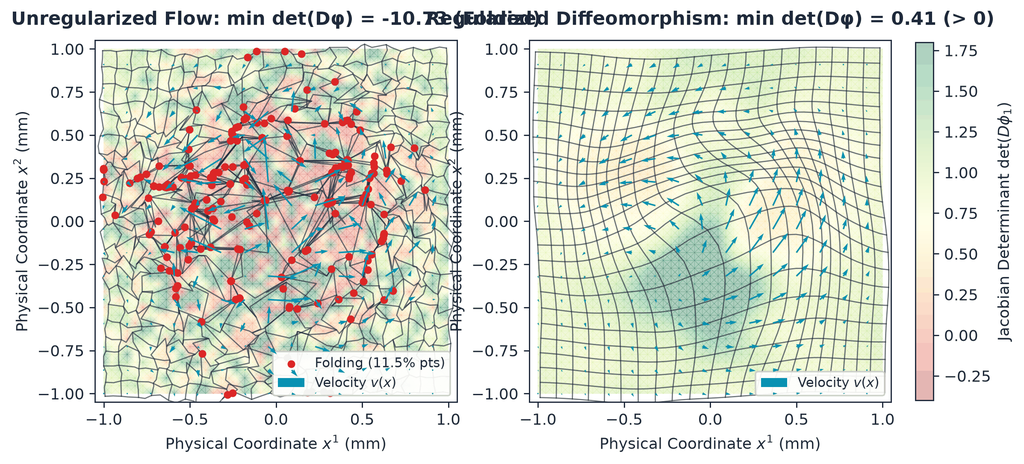

Figure 1: Discrete 8-step forward integration of an unregularized high-frequency velocity field violates Lipschitz bounds and folds the Lagrangian mesh (min det(Dφ_1) < 0, crimson markers), whereas elliptic regularization preserves positive Jacobian determinants everywhere.

```python
from pathlib import Path
import numpy as np
import matplotlib.pyplot as plt
from scipy.ndimage import gaussian_filter

Path("figures").mkdir(parents=True, exist_ok=True)
plt.rcParams.update({
    "figure.facecolor": "#ffffff",
    "axes.facecolor": "#ffffff",
    "axes.edgecolor": "#1e293b",
    "text.color": "#1e293b",
    "axes.labelcolor": "#1e293b",
    "xtick.color": "#1e293b",
    "ytick.color": "#1e293b",
    "font.size": 10,
})

rng = np.random.default_rng(42)
N = 45
x1 = np.linspace(-1.0, 1.0, N)
x2 = np.linspace(-1.0, 1.0, N)
X1, X2 = np.meshgrid(x1, x2, indexing="ij")
dx = x1[1] - x1[0]

r2 = X1**2 + X2**2
envelope = np.exp(-2.2 * r2)
v1_base = -0.55 * X2 * envelope + 0.25 * np.sin(np.pi * X1) * envelope
v2_base =  0.55 * X1 * envelope + 0.25 * np.cos(np.pi * X2) * envelope

v1_raw = v1_base + 0.34 * rng.standard_normal((N, N)) * envelope
v2_raw = v2_base + 0.34 * rng.standard_normal((N, N)) * envelope

v1_reg = gaussian_filter(v1_raw, sigma=2.8, mode="nearest") * 1.25
v2_reg = gaussian_filter(v2_raw, sigma=2.8, mode="nearest") * 1.25

def integrate_flow(vx, vy, steps=8):
    px, py = X1.copy(), X2.copy()
    dt = 1.0 / steps
    for _ in range(steps):
        ix = np.clip((px + 1.0) / dx, 0, N - 1.001)
        iy = np.clip((py + 1.0) / dx, 0, N - 1.001)
        i0, j0 = ix.astype(int), iy.astype(int)
        wx, wy = ix - i0, iy - j0
        ux = ((1 - wx) * (1 - wy) * vx[i0, j0] + wx * (1 - wy) * vx[i0 + 1, j0]
              + (1 - wx) * wy * vx[i0, j0 + 1] + wx * wy * vx[i0 + 1, j0 + 1])
        uy = ((1 - wx) * (1 - wy) * vy[i0, j0] + wx * (1 - wy) * vy[i0 + 1, j0]
              + (1 - wx) * wy * vy[i0, j0 + 1] + wx * wy * vy[i0 + 1, j0 + 1])
        px = px + dt * ux
        py = py + dt * uy
    dpx_dx, dpx_dy = np.gradient(px, dx, dx, edge_order=2)
    dpy_dx, dpy_dy = np.gradient(py, dx, dx, edge_order=2)
    det_J = dpx_dx * dpy_dy - dpx_dy * dpy_dx
    return px, py, det_J

phi_raw_x, phi_raw_y, det_raw = integrate_flow(v1_raw, v2_raw)
phi_reg_x, phi_reg_y, det_reg = integrate_flow(v1_reg, v2_reg)

fig, axes = plt.subplots(1, 2, figsize=(11.2, 5.1))

panels = [
    (axes[0], phi_raw_x, phi_raw_y, v1_raw, v2_raw, det_raw,
     f"Unregularized Flow: min det(Dφ) = {det_raw.min():.2f} (Folded)"),
    (axes[1], phi_reg_x, phi_reg_y, v1_reg, v2_reg, det_reg,
     f"Regularized Diffeomorphism: min det(Dφ) = {det_reg.min():.2f} (> 0)"),
]

for ax, px, py, vx, vy, detJ, title in panels:
    cf = ax.pcolormesh(
        X1, X2, np.clip(detJ, -0.5, 2.0),
        cmap="RdYlGn", vmin=-0.4, vmax=1.8, shading="gouraud", alpha=0.32
    )
    for i in range(0, N, 2):
        ax.plot(px[i, :], py[i, :], color="#1e293b", lw=0.75, alpha=0.65)
        ax.plot(px[:, i], py[:, i], color="#1e293b", lw=0.75, alpha=0.65)
    fold_mask = detJ <= 0.0
    if np.any(fold_mask):
        ax.scatter(
            px[fold_mask], py[fold_mask], color="#dc2626", s=16, zorder=5,
            label=f"Folding ({100.0 * fold_mask.mean():.1f}% pts)"
        )
    ax.quiver(
        X1[::3, ::3], X2[::3, ::3], vx[::3, ::3], vy[::3, ::3],
        color="#0891b2", angles="xy", scale_units="xy", scale=3.2,
        width=0.0042, zorder=6, label="Velocity $v(x)$"
    )
    ax.set_title(title, fontweight="bold", pad=10)
    ax.set_xlabel("Physical Coordinate $x^1$ (mm)")
    ax.set_ylabel("Physical Coordinate $x^2$ (mm)")
    ax.set_xlim(-1.05, 1.05)
    ax.set_ylim(-1.05, 1.05)
    ax.set_aspect("equal")
    ax.legend(loc="lower right", frameon=True, facecolor="#ffffff", framealpha=0.92, fontsize=8.5)

cbar = fig.colorbar(cf, ax=axes.ravel().tolist(), shrink=0.82, pad=0.025)
cbar.set_label("Jacobian Determinant $\\det(D\\phi_1)$")
fig.savefig("figures/fig_sec1_folding_vs_diffeo.png", dpi=160, bbox_inches="tight", facecolor="#ffffff")
plt.show()
```

**NoteGenerative 3D Illustration Prompt**

**Prompt:** Create a split-screen 3D scientific architectural visualization set against a pure matte white studio background (`#ffffff`) with soft directional global illumination. On the left half, render a curved 3D undulating surface covered by a fine slate-gray wireframe coordinate mesh being torn, crinkled, and self-intersected by chaotic, colliding 3D amber and crimson vector arrows pointing at erratic angles, creating sharp folded creases and mesh overlaps. On the right half, render the exact same curved 3D surface covered by a continuous, non-overlapping coordinate grid deformed smoothly by sleek cyan and emerald 3D streamlines gliding tangentially over the surface in laminar order. Emphasize crisp 3D depth, subtle specular surface reflections, and razor-sharp wireframe geometry. **CRITICAL CONSTRAINT: Include ZERO text, ZERO numbers, ZERO mathematical symbols, ZERO equations, and ZERO axis labels anywhere in the image.**

# 2 The Variational Energy Minimization Formulation

## 2.1 Harmonic Map Action on Coupled Manifolds

Homogeneous linear regularizers—such as isotropic Gaussian filtering or constant-coefficient Sobolev operators $(I - \alpha \Delta)^s$—apply spatially uniform smoothing across the entire image domain. While mathematically convenient via Fast Fourier Transform (FFT) diagonalization, uniform quadratic smoothing penalizes genuine physiological shear discontinuities (such as pleural lung sliding, dural brain interfaces, or myocardial wall motion) just as heavily as noise.

To make velocity regularization **geometry-aware**, the Beltrami framework (Sochen, Kimmel, & Malladi, 1998, generalizing Eells & Sampson, 1964 harmonic map energy) models the velocity field as a smooth map $v : (M, g) \to (N, h)$ from a $d$-dimensional **domain Riemannian manifold** $(M, g)$ into a $d$-dimensional **velocity fiber manifold** $(N, h)$, and minimizes the **Polyakov / generalized Dirichlet–Beltrami action**:

$$E_{\text{Beltrami}}(v)
= \frac{1}{2} \int_M \| \nabla v \|_{g,h}^2 \, dV_g
= \frac{1}{2} \int_\Omega g^{ij}(x) \, h_{\alpha\beta}\bigl(v(x)\bigr) \, \bigl(\nabla_i v^\alpha(x)\bigr) \, \bigl(\nabla_j v^\beta(x)\bigr) \sqrt{\det\bigl(g(x)\bigr)} \, dx^1 \cdots dx^d.$$

At each point $x \in \Omega$, the integrand contracts the two-point differential $\nabla_i v^\alpha$ across domain directions $(i, j)$ via the contravariant inverse metric $g^{ij}(x)$ and across velocity fiber components $(\alpha, \beta)$ via $h_{\alpha\beta}(v)$:

$$\| \nabla v(x) \|_{g,h}^2 = \sum_{i=1}^d \sum_{j=1}^d \sum_{\alpha=1}^d \sum_{\beta=1}^d g^{ij}(x) \, h_{\alpha\beta}\bigl(v(x)\bigr) \, (\nabla_i v^\alpha) \, (\nabla_j v^\beta).$$

When the velocity target space carries the canonical Euclidean fiber metric $h_{\alpha\beta} = \delta_{\alpha\beta}$, we denote $\| \nabla v \|_{g,h}^2$ compactly as $\| \nabla v \|_g^2$. Every geometric property of Beltrami regularization stems from the interplay of four explicit factors in this integrand: $g_{ij}$, $g^{ij}$, $\sqrt{\det(g)}$, and $\nabla_i v^\alpha$.

## 2.2 Term-by-Term Mathematical Dictionary

- $E_{\text{Beltrami}} : C^\infty(M, N) \to \mathbb{R}_{\ge 0}$: **Beltrami harmonic energy functional** — Non-negative scalar variational action measuring total metric-weighted velocity strain energy; rank-0 functional.
- $(M, g)$: **Domain Riemannian manifold** — Smooth $d$-dimensional base manifold parameterized over $\Omega \subset \mathbb{R}^d$ with metric tensor $g$.
- $g_{ij}(x)$: **Covariant domain metric tensor** — Symmetric positive-definite rank-$(0,2)$ tensor field $M \to T^*M \otimes_S T^*M$ defining local tangent inner products; domain indices $i, j \in \{1, \dots, d\}$.
- $g^{ij}(x)$: **Contravariant inverse domain metric** — Symmetric positive-definite rank-$(2,0)$ tensor field $M \to TM \otimes_S TM$ satisfying $\sum_{k=1}^d g^{ik}(x) g_{kj}(x) = \delta^i{}_j$.
- $(N, h)$ and $h_{\alpha\beta}(v)$: **Velocity fiber manifold & fiber metric tensor** — $d$-dimensional target space $N \cong \mathbb{R}^d$ equipped with symmetric positive-definite rank-$(0,2)$ metric $h_{\alpha\beta} : N \to T^*N \otimes_S T^*N$; fiber indices $\alpha, \beta \in \{1, \dots, d\}$.
- $\nabla_i v^\alpha(x)$: **Covariant velocity differential** — Rank-$(1,1)$ section of $T^*M \otimes v^{-1}TN$ measuring the rate of change of velocity component $\alpha$ along domain coordinate $x^i$.
- $\| \nabla v \|_g^2 : M \to \mathbb{R}_{\ge 0}$: **Intrinsic Hilbert–Schmidt norm squared** — Coordinate-invariant rank-0 scalar trace of $\nabla v$ under metrics $(g, h)$.
- $\det\bigl(g(x)\bigr) \equiv |g(x)| : \Omega \to \mathbb{R}_{> 0}$: **Metric determinant** — Determinant of the $d \times d$ matrix $[g_{ij}(x)]$; scalar density of weight $+2$.
- $dV_g = \sqrt{\det(g(x))}\, dx^1 \cdots dx^d$: **Induced Riemannian volume form** — Coordinate-invariant $d$-form $\Omega^d(M)$ guaranteeing reparameterization invariance of $E_{\text{Beltrami}}(v)$.

## 2.3 Paired Numerical Verification & 3D Manifold Prompt

**Show deterministic Python verification & figure export code**

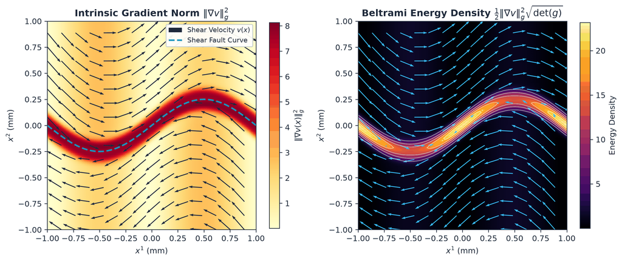

Figure 2: Curved tangential shear fault in a 2D velocity field: intrinsic gradient norm squared ||∇v||_g^2 (left) and full Beltrami integrand density 1/2 ||∇v||_g^2 √det(g) (right), localizing variational strain energy cleanly along the shear interface.

```python
from pathlib import Path
import numpy as np
import matplotlib.pyplot as plt

Path("figures").mkdir(parents=True, exist_ok=True)
N = 90
x = np.linspace(-1.0, 1.0, N)
y = np.linspace(-1.0, 1.0, N)
X, Y = np.meshgrid(x, y, indexing="ij")
dx = x[1] - x[0]

fault = Y - 0.25 * np.sin(np.pi * X)
sharpness = 14.0
v1 = 0.75 * np.tanh(sharpness * fault) - 0.15 * Y
v2 = 0.75 * 0.25 * np.pi * np.cos(np.pi * X) * np.tanh(sharpness * fault) + 0.15 * X

dv1_dx, dv1_dy = np.gradient(v1, dx, dx, edge_order=2)
dv2_dx, dv2_dy = np.gradient(v2, dx, dx, edge_order=2)

alpha = 0.35
g11 = 1.0 + alpha**2 * (dv1_dx**2 + dv2_dx**2)
g12 = alpha**2 * (dv1_dx * dv1_dy + dv2_dx * dv2_dy)
g22 = 1.0 + alpha**2 * (dv1_dy**2 + dv2_dy**2)

det_g = g11 * g22 - g12**2
sqrt_det_g = np.sqrt(det_g)

g_inv11, g_inv12, g_inv22 = g22 / det_g, -g12 / det_g, g11 / det_g

S11 = dv1_dx**2 + dv2_dx**2
S12 = dv1_dx * dv1_dy + dv2_dx * dv2_dy
S22 = dv1_dy**2 + dv2_dy**2
norm_grad_v_g2 = g_inv11 * S11 + 2.0 * g_inv12 * S12 + g_inv22 * S22
beltrami_integrand = 0.5 * norm_grad_v_g2 * sqrt_det_g

fig, axes = plt.subplots(1, 2, figsize=(11.2, 4.9))

im0 = axes[0].pcolormesh(X, Y, norm_grad_v_g2, cmap="YlOrRd", shading="gouraud")
s = 6
axes[0].quiver(
    X[::s, ::s], Y[::s, ::s], v1[::s, ::s], v2[::s, ::s],
    color="#1e293b", angles="xy", scale_units="xy", scale=5.0, width=0.004,
    label="Shear Velocity $v(x)$"
)
axes[0].plot(x, 0.25 * np.sin(np.pi * x), "--", color="#0891b2", lw=2.0, label="Shear Fault Curve")
axes[0].set_title("Intrinsic Gradient Norm $\\|\\nabla v\\|_g^2$", fontweight="bold")
axes[0].set_xlabel("$x^1$ (mm)")
axes[0].set_ylabel("$x^2$ (mm)")
axes[0].set_aspect("equal")
axes[0].legend(loc="upper right", facecolor="#ffffff", framealpha=0.92, fontsize=8.5)
fig.colorbar(im0, ax=axes[0], shrink=0.82, label="$\\|\\nabla v(x)\\|_g^2$")

im1 = axes[1].pcolormesh(X, Y, beltrami_integrand, cmap="inferno", shading="gouraud")
axes[1].contour(X, Y, beltrami_integrand, levels=5, colors="#ffffff", linewidths=0.7, alpha=0.65)
axes[1].quiver(
    X[::s, ::s], Y[::s, ::s], v1[::s, ::s], v2[::s, ::s],
    color="#38bdf8", angles="xy", scale_units="xy", scale=5.0, width=0.0038
)
axes[1].set_title("Beltrami Energy Density $\\frac{1}{2}\\|\\nabla v\\|_g^2 \\sqrt{\\det(g)}$", fontweight="bold")
axes[1].set_xlabel("$x^1$ (mm)")
axes[1].set_ylabel("$x^2$ (mm)")
axes[1].set_aspect("equal")
fig.colorbar(im1, ax=axes[1], shrink=0.82, label="Energy Density")

plt.tight_layout()
fig.savefig("figures/fig_sec2_energy_density.png", dpi=160, bbox_inches="tight", facecolor="#ffffff")
plt.show()
```

**NoteGenerative 3D Illustration Prompt**

**Prompt:** Render a 3D translucent elastic membrane suspended above a flat reference plane in a bright, minimalist white studio (`#ffffff`). Underneath the membrane, sleek 3D metallic flow vectors glide in two opposing S-curved currents separated by a narrow central shear boundary. In the smooth laminar regions on either side, the elastic membrane lies calm, flat, and tinted in cool translucent sapphire and cyan. Along the central S-curved shear zone where opposing currents brush past each other, the membrane stretches taut into a raised ridge glowing intensely in luminous amber, incandescent orange, and white-hot gold to depict concentrated strain energy density. **CRITICAL CONSTRAINT: Include ZERO text, ZERO numbers, ZERO mathematical symbols, ZERO equations, and ZERO labels anywhere in the image.**

# 3 Term 1 — The Induced Metric Tensor ($g_{ij}$) & Manifold Embedding

## 3.1 Space-Feature Pullback Geometry

The Beltrami formulation avoids arbitrary edge-stopping heuristics by deriving $g_{ij}(x)$ geometrically as a **pullback metric**. Define the smooth **graph immersion** $\Psi : \Omega \to \mathbb{R}^d \times \mathbb{R}^d$ embedding spatial coordinates and scaled velocity components jointly into a $2d$-dimensional ambient product space:

$$\Psi(x) = \bigl(x^1, \dots, x^d, \, \alpha v^1(x), \dots, \alpha v^d(x)\bigr) \in \mathbb{R}^{2d},$$

*(Note: In anatomy-guided registration, $\Psi$ can alternatively or jointly append normalized image feature channels $\beta I^c(x)$ so metric barriers lock onto tissue boundaries directly.)* Equipping $\mathbb{R}^{2d}$ with the Euclidean metric $\bar{g} = \sum_{i=1}^d (dx^i)^2 + \sum_{\gamma=1}^d (dz^\gamma)^2$, the **pullback metric** $g = \Psi^*\bar{g}$ on $\Omega$ evaluates inner products of pushed-forward basis vectors $\partial_i \Psi$:

$$g_{ij}(x)
= \left\langle \frac{\partial \Psi(x)}{\partial x^i}, \frac{\partial \Psi(x)}{\partial x^j} \right\rangle_{\mathbb{R}^{2d}}
= \delta_{ij} + \alpha^2 \sum_{\gamma=1}^d \left(\frac{\partial v^\gamma(x)}{\partial x^i}\right)\left(\frac{\partial v^\gamma(x)}{\partial x^j}\right).$$

For an infinitesimal base-space displacement $dx = (dx^1, \dots, dx^d)$, the induced **first fundamental form** (squared manifold arc length $ds^2$) sums spatial Euclidean distance and velocity variation in quadrature:

$$ds^2 = g_{ij}(x) \, dx^i \, dx^j = \sum_{i=1}^d (dx^i)^2 + \alpha^2 \sum_{\gamma=1}^d (dv^\gamma)^2, \qquad dv^\gamma = \sum_{i=1}^d \frac{\partial v^\gamma}{\partial x^i} dx^i.$$

Consequently, $g_{ij}(x)$ is symmetric positive-definite with eigenvalues bounded below by $1$. In regions of uniform velocity ($\partial_i v^\gamma = 0$), $g_{ij} = \delta_{ij}$ reduces to flat Euclidean space. Across a shear cliff where $|\partial_i v^\gamma| \gg \alpha^{-1}$, the manifold distance $ds$ between adjacent voxels dilates dramatically, erecting a geometric barrier between distinct motion regimes.

## 3.2 Term-by-Term Mathematical Dictionary

- $\Psi : \Omega \to \mathbb{R}^{2d}$: **Space-velocity graph immersion** — Smooth embedding mapping spatial coordinate $x \in \Omega$ onto the $d$-dimensional graph submanifold $M = \Psi(\Omega) \subset \mathbb{R}^{2d}$; rank-0 manifold map.
- $g_{ij}(x) = (\Psi^*\bar{g})_{ij}(x)$: **Induced pullback metric tensor** — Symmetric positive-definite rank-$(0,2)$ covariant tensor measuring intrinsic distances on $\Psi(\Omega)$.
- $\delta_{ij} \in \{0, 1\}$: **Covariant Kronecker delta** — Rank-$(0,2)$ Euclidean metric baseline ($\delta_{ij} = 1$ if $i=j$, $0$ if $i \neq j$).
- $\alpha \in \mathbb{R}_{\ge 0}$: **Metric coupling scale** — Dimensional ratio ($[\text{mm}]/[\text{velocity unit}]$) converting velocity jumps into equivalent spatial millimeters; $\alpha = 0$ recovers flat Euclidean geometry.
- $\gamma \in \{1, \dots, d\}$: **Velocity fiber index** — Summation index spanning the $d$ velocity components $(v^1, \dots, v^d)$.
- $\partial_i v^\gamma \equiv \frac{\partial v^\gamma}{\partial x^i} : \Omega \to \mathbb{R}$: **Spatial partial derivative** — Coordinate derivative of velocity component $\gamma$ along physical axis $x^i$.
- $dx^i \in T^*_x\Omega$: **Coordinate basis 1-form** — Infinitesimal coordinate increment along axis $i$; rank-$(0,1)$ covector.
- $dv^\gamma = (\partial_i v^\gamma) dx^i \in T^*_x\Omega$: **Differential of velocity component $\gamma$** — Linearized velocity change over step $dx$; rank-$(0,1)$ 1-form.
- $ds^2 = g_{ij} dx^i dx^j$: **Riemannian line element** — Quadratic form $T_x\Omega \times T_x\Omega \to \mathbb{R}_{\ge 0}$ giving squared arc length on $(M, g)$.

## 3.3 Paired Numerical Verification & 3D Manifold Prompt

**Show deterministic Python verification & figure export code**

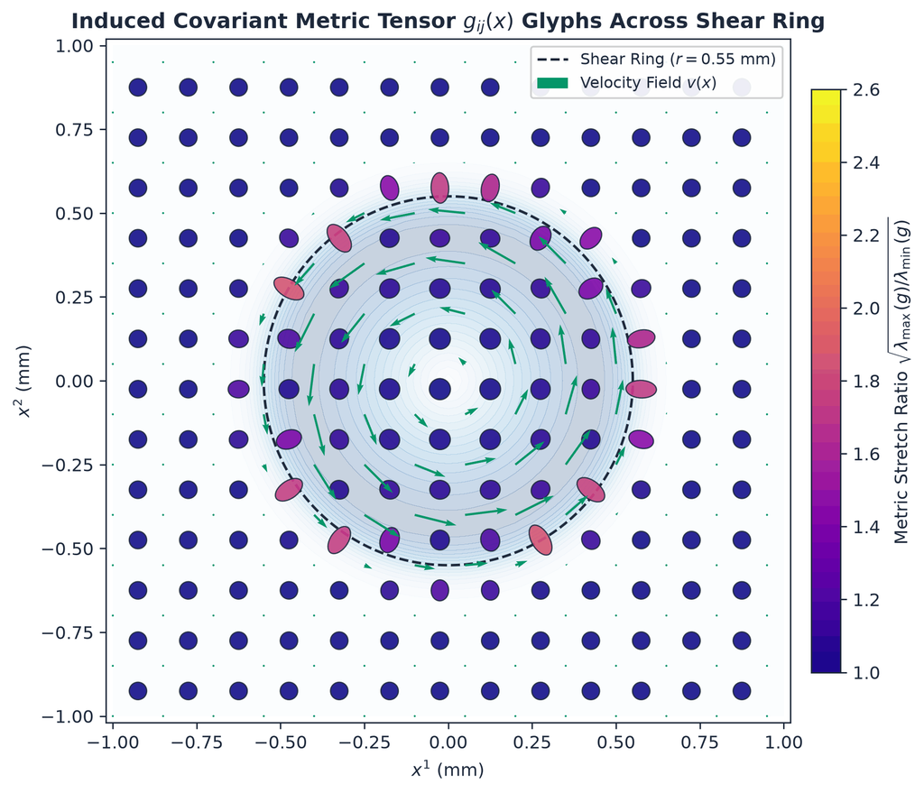

Figure 3: Covariant metric stretch glyphs (principal semi-axes proportional to √λ_k(g)) across a rotational core bounded by a sharp radial shear ring (r = 0.55). Glyphs remain isotropic unit circles on smooth interior/exterior regions and elongate radially across the high-shear transition.

```python
from pathlib import Path
import numpy as np
import matplotlib.pyplot as plt
from matplotlib.patches import Ellipse
from matplotlib.cm import ScalarMappable
from matplotlib.colors import Normalize

Path("figures").mkdir(parents=True, exist_ok=True)
N = 81
x = np.linspace(-1.0, 1.0, N)
y = np.linspace(-1.0, 1.0, N)
X, Y = np.meshgrid(x, y, indexing="ij")
dx = x[1] - x[0]

R = np.hypot(X, Y) + 1e-8
R0 = 0.55
gate = 0.5 * (1.0 - np.tanh(14.0 * (R - R0)))
v1 = -0.85 * (Y / R) * np.sin(0.5 * np.pi * np.clip(R / R0, 0, 1)) * gate
v2 =  0.85 * (X / R) * np.sin(0.5 * np.pi * np.clip(R / R0, 0, 1)) * gate

dv1_dx, dv1_dy = np.gradient(v1, dx, dx, edge_order=2)
dv2_dx, dv2_dy = np.gradient(v2, dx, dx, edge_order=2)

alpha = 0.28
g11 = 1.0 + alpha**2 * (dv1_dx**2 + dv2_dx**2)
g12 = alpha**2 * (dv1_dx * dv1_dy + dv2_dx * dv2_dy)
g22 = 1.0 + alpha**2 * (dv1_dy**2 + dv2_dy**2)

fig, ax = plt.subplots(figsize=(7.6, 6.4))

speed = np.hypot(v1, v2)
ax.contourf(X, Y, speed, levels=16, cmap="Blues", alpha=0.22)
theta_ring = np.linspace(0, 2 * np.pi, 240)
ax.plot(R0 * np.cos(theta_ring), R0 * np.sin(theta_ring), "--", color="#1e293b", lw=1.4,
        label="Shear Ring ($r = 0.55$ mm)")

step = 6
norm = Normalize(vmin=1.0, vmax=2.6)
cmap = plt.cm.plasma

for i in range(3, N - 3, step):
    for j in range(3, N - 3, step):
        G = np.array([[g11[i, j], g12[i, j]], [g12[i, j], g22[i, j]]])
        evals, evecs = np.linalg.eigh(G)
        angle_deg = np.degrees(np.arctan2(evecs[1, 1], evecs[0, 1]))
        scale_glyph = 0.052
        aniso = np.sqrt(evals[1] / evals[0])
        ell = Ellipse(
            xy=(X[i, j], Y[i, j]),
            width=scale_glyph * np.sqrt(evals[1]),
            height=scale_glyph * np.sqrt(evals[0]),
            angle=angle_deg,
            facecolor=cmap(norm(aniso)), edgecolor="#1e293b", lw=0.7, alpha=0.88, zorder=4
        )
        ax.add_patch(ell)

ax.quiver(
    X[::6, ::6], Y[::6, ::6], v1[::6, ::6], v2[::6, ::6],
    color="#059669", angles="xy", scale_units="xy", scale=6.0, width=0.0032, zorder=5,
    label="Velocity Field $v(x)$"
)

sm = ScalarMappable(norm=norm, cmap=cmap)
sm.set_array([])
cbar = fig.colorbar(sm, ax=ax, shrink=0.84, pad=0.025)
cbar.set_label("Metric Stretch Ratio $\\sqrt{\\lambda_{\\max}(g) / \\lambda_{\\min}(g)}$")

ax.set_title("Induced Covariant Metric Tensor $g_{ij}(x)$ Glyphs Across Shear Ring", fontweight="bold")
ax.set_xlabel("$x^1$ (mm)")
ax.set_ylabel("$x^2$ (mm)")
ax.set_xlim(-1.02, 1.02)
ax.set_ylim(-1.02, 1.02)
ax.set_aspect("equal")
ax.legend(loc="upper right", facecolor="#ffffff", framealpha=0.92, fontsize=8.8)
plt.tight_layout()
fig.savefig("figures/fig_sec3_metric_ellipses.png", dpi=160, bbox_inches="tight", facecolor="#ffffff")
plt.show()
```

**NoteGenerative 3D Illustration Prompt**

**Prompt:** Create a crisp 3D geometric illustration on a pure white studio background (`#ffffff`) showing a flat 2D slate-gray Cartesian coordinate grid on the bottom floor smoothly lifting upward into a 3D sculpted topographic circular plateau with steep cliff walls around its perimeter. On the flat valley floor and flat plateau summit, render small horizontal translucent cyan glass tangent squares sitting level with the surface. Along the steep circular cliff slope where elevation changes rapidly, render elongated, steeply tilted translucent amber glass tangent rectangles clinging flush to the cliff face, visually demonstrating how horizontal base steps stretch into long sloped distances on the manifold. **CRITICAL CONSTRAINT: Include ZERO text, ZERO numbers, ZERO mathematical symbols, ZERO equations, and ZERO labels anywhere in the image.**

# 4 Term 2 — The Inverse Metric Tensor ($g^{ij}$) as an Anisotropic Diffusion Tensor

## 4.1 Spectral Rotation & Directional Conductance

Whereas $g_{ij}$ measures arc-length stretching, the Beltrami energy and differential operator contract derivatives through its matrix inverse—the **contravariant metric tensor** $g^{ij}(x) = \bigl(g(x)^{-1}\bigr)^{ij}$, satisfying $\sum_{k=1}^d g^{ik}(x) g_{kj}(x) = \delta^i{}_j$. For $d = 2$, explicit inversion gives:

$$\begin{pmatrix} g^{11}(x) & g^{12}(x) \\ g^{21}(x) & g^{22}(x) \end{pmatrix}
= \frac{1}{g_{11}(x) g_{22}(x) - \bigl(g_{12}(x)\bigr)^2}
\begin{pmatrix} g_{22}(x) & -g_{12}(x) \\ -g_{21}(x) & g_{11}(x) \end{pmatrix}.$$

Diagonalizing the symmetric positive-definite matrix $g_{ij}(x)$ in a local orthonormal frame $\{e_1(x), e_2(x)\}$ with eigenvalues $\lambda_1(x) \ge \lambda_2(x) \ge 1$ immediately reveals the anisotropic diffusivity structure of $g^{ij}(x)$:

$$g_{ij}(x) = \lambda_1(x) \, e_{1,i}(x) e_{1,j}(x) + \lambda_2(x) \, e_{2,i}(x) e_{2,j}(x)
\quad \Longrightarrow \quad
g^{ij}(x) = \underbrace{\frac{1}{\lambda_1(x)}}_{\mu_1(x) \in (0, 1]} e_1^i(x) e_1^j(x) + \underbrace{\frac{1}{\lambda_2(x)}}_{\mu_2(x) \in (0, 1]} e_2^i(x) e_2^j(x).$$

Along a physiological sliding boundary with unit normal $e_1$ (perpendicular to the interface) and unit tangent $e_2$ (parallel to streamlines):

1. **Cross-Boundary Inhibition ($e_1$)**: High normal shear $|\nabla_{e_1} v| \gg \alpha^{-1}$ drives $\lambda_1 = 1 + \alpha^2 |\nabla_{e_1} v|^2 \gg 1$, collapsing normal diffusivity $\mu_1 = \lambda_1^{-1} \to 0$. Momentum flux across the anatomical interface is shut off.
2. **Streamline-Parallel Smoothing ($e_2$)**: Tangential variation along the coherent interface remains small ($|\nabla_{e_2} v| \approx 0 \implies \lambda_2 \approx 1$), maintaining full tangential diffusivity $\mu_2 = \lambda_2^{-1} \approx 1$ to damp tangential noise without rounding the discontinuity.

## 4.2 Term-by-Term Mathematical Dictionary

- $g^{ij}(x)$: **Contravariant inverse metric (diffusion tensor)** — Symmetric positive-definite rank-$(2,0)$ tensor field $\Omega \to TM \otimes_S TM$ governing directional momentum diffusivity.
- $\delta^i{}_j \in \{0, 1\}$: **Mixed Kronecker delta** — Rank-$(1,1)$ identity endomorphism on $T_x\Omega$.
- $e_1(x), e_2(x) \in \mathbb{R}^d$: **Orthonormal principal eigenvectors** — Unit vectors ($\langle e_a, e_b \rangle = \delta_{ab}$) aligned with maximum velocity strain ($e_1$, fault normal) and minimum velocity strain ($e_2$, fault tangent / streamline).
- $\lambda_1(x), \lambda_2(x) \in [1, \infty)$: **Principal covariant stretch eigenvalues** — Eigenvalues of $g_{ij}(x)$ ordered $\lambda_1(x) \ge \lambda_2(x) \ge 1$.
- $\mu_1(x) = \lambda_1(x)^{-1}, \; \mu_2(x) = \lambda_2(x)^{-1} \in (0, 1]$: **Principal contravariant conductances** — Reciprocal eigenvalues scaling diffusive flux across ($\mu_1 \ll 1$) versus along ($\mu_2 \approx 1$) shear layers.

## 4.3 Paired Numerical Verification & 3D Manifold Prompt

**Show deterministic Python verification & figure export code**

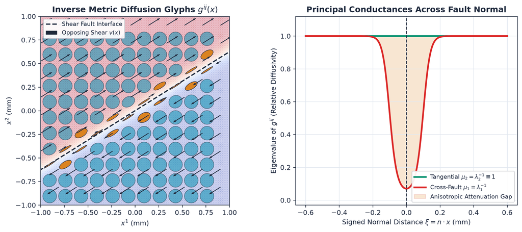

Figure 4: Left: Inverse metric diffusion glyphs g^{ij}(x) across a 32° inclined shear plane pinch flat along fault normal e_1 while retaining full span parallel to fault tangent e_2. Right: Exact normal cross-section of conductances μ_1 = λ_1^{-1} and μ_2 = λ_2^{-1}.

```python
from pathlib import Path
import numpy as np
import matplotlib.pyplot as plt
from matplotlib.patches import Ellipse

Path("figures").mkdir(parents=True, exist_ok=True)
N = 85
x = np.linspace(-1.0, 1.0, N)
y = np.linspace(-1.0, 1.0, N)
X, Y = np.meshgrid(x, y, indexing="ij")
dx = x[1] - x[0]

theta = np.radians(32.0)
t_vec = np.array([np.cos(theta), np.sin(theta)])
n_vec = np.array([-np.sin(theta), np.cos(theta)])

signed_dist = X * n_vec[0] + Y * n_vec[1]
shear_profile = np.tanh(13.0 * signed_dist)
v1 = 0.80 * shear_profile * t_vec[0]
v2 = 0.80 * shear_profile * t_vec[1]

dv1_dx, dv1_dy = np.gradient(v1, dx, dx, edge_order=2)
dv2_dx, dv2_dy = np.gradient(v2, dx, dx, edge_order=2)

alpha = 0.35
g11 = 1.0 + alpha**2 * (dv1_dx**2 + dv2_dx**2)
g12 = alpha**2 * (dv1_dx * dv1_dy + dv2_dx * dv2_dy)
g22 = 1.0 + alpha**2 * (dv1_dy**2 + dv2_dy**2)
det_g = g11 * g22 - g12**2

ginv11, ginv12, ginv22 = g22 / det_g, -g12 / det_g, g11 / det_g

fig, (ax0, ax1) = plt.subplots(1, 2, figsize=(11.4, 4.9), gridspec_kw={"width_ratios": [1.22, 1.0]})

ax0.pcolormesh(X, Y, shear_profile, cmap="coolwarm", alpha=0.22, shading="gouraud")
line_s = np.linspace(-1.2, 1.2, 100)
ax0.plot(line_s * t_vec[0], line_s * t_vec[1], "--", color="#1e293b", lw=1.8, label="Shear Fault Interface")

for i in range(4, N - 4, 7):
    for j in range(4, N - 4, 7):
        Ginv = np.array([[ginv11[i, j], ginv12[i, j]], [ginv12[i, j], ginv22[i, j]]])
        mu_vals, evecs = np.linalg.eigh(Ginv)
        angle_deg = np.degrees(np.arctan2(evecs[1, 1], evecs[0, 1]))
        glyph_scale = 0.145
        is_edge = mu_vals[0] < 0.65
        ell = Ellipse(
            xy=(X[i, j], Y[i, j]),
            width=glyph_scale * mu_vals[1],
            height=glyph_scale * mu_vals[0],
            angle=angle_deg,
            facecolor="#d97706" if is_edge else "#0891b2",
            edgecolor="#1e293b",
            lw=0.75,
            alpha=0.88 if is_edge else 0.55,
            zorder=4,
        )
        ax0.add_patch(ell)

ax0.quiver(
    X[::8, ::8], Y[::8, ::8], v1[::8, ::8], v2[::8, ::8],
    color="#1e293b", angles="xy", scale_units="xy", scale=5.5, width=0.0036, zorder=5,
    label="Opposing Shear $v(x)$"
)
ax0.set_xlim(-1.0, 1.0)
ax0.set_ylim(-1.0, 1.0)
ax0.set_aspect("equal")
ax0.set_title("Inverse Metric Diffusion Glyphs $g^{ij}(x)$", fontweight="bold")
ax0.set_xlabel("$x^1$ (mm)")
ax0.set_ylabel("$x^2$ (mm)")
ax0.legend(loc="upper left", facecolor="#ffffff", framealpha=0.92, fontsize=8.5)

xi = np.linspace(-0.6, 0.6, 400)
dv_dn = 0.80 * 13.0 * (1.0 / np.cosh(13.0 * xi)**2)
mu_1 = 1.0 / (1.0 + alpha**2 * dv_dn**2)
mu_2 = np.ones_like(xi)

ax1.plot(xi, mu_2, color="#059669", lw=2.5, label="Tangential $\\mu_2 = \\lambda_2^{-1} \\equiv 1$")
ax1.plot(xi, mu_1, color="#dc2626", lw=2.5, label="Cross-Fault $\\mu_1 = \\lambda_1^{-1}$")
ax1.fill_between(xi, mu_1, mu_2, color="#d97706", alpha=0.18, label="Anisotropic Attenuation Gap")
ax1.axvline(0.0, color="#1e293b", ls="--", lw=1.2)
ax1.set_title("Principal Conductances Across Fault Normal", fontweight="bold")
ax1.set_xlabel("Signed Normal Distance $\\xi = n \\cdot x$ (mm)")
ax1.set_ylabel("Eigenvalue of $g^{ij}$ (Relative Diffusivity)")
ax1.set_ylim(-0.03, 1.12)
ax1.grid(True, color="#e2e8f0", lw=0.8)
ax1.legend(loc="lower right", facecolor="#ffffff", framealpha=0.95, fontsize=8.5)

plt.tight_layout()
fig.savefig("figures/fig_sec4_inverse_metric_diffusion.png", dpi=160, bbox_inches="tight", facecolor="#ffffff")
plt.show()
```

**NoteGenerative 3D Illustration Prompt**

**Prompt:** Render a high-precision 3D scientific glyph visualization in a clean white studio (`#ffffff`) showing two opposing laminar fluid streams—one cool emerald on the left, one deep sapphire on the right—gliding past each other along a vertical glass-like shear plane. Distributed throughout both fluid volumes are 3D glossy ellipsoids representing local diffusion tensors: far from the boundary, the glyphs are plump, nearly spherical cyan orbs; right along the central shear boundary wall, the 3D ellipsoids flatten into razor-thin amber discs pressed parallel against the boundary plane, visually illustrating diffusion flowing freely along the wall while blocked from crossing through it. **CRITICAL CONSTRAINT: Include ZERO text, ZERO numbers, ZERO mathematical symbols, ZERO equations, and ZERO labels anywhere in the image.**

# 5 Term 3 — The Volume Density Element ($\sqrt{|g|}$)

## 5.1 Reparameterization Invariance & Minimal Graph Area

In general coordinates $(x^1, \dots, x^d)$, the coordinate volume element $dx^1 \wedge \dots \wedge dx^d$ scales by the Jacobian of coordinate transformations and therefore cannot define a physical integral by itself. Because $g_{ij}$ transforms covariantly as $\tilde{g}_{ab} = \frac{\partial x^i}{\partial \tilde{x}^a}\frac{\partial x^j}{\partial \tilde{x}^b} g_{ij}$, its determinant $|g| \equiv \det(g_{ij})$ transforms with square Jacobian weight, rendering the **Riemannian volume form** strictly invariant:

$$dV_g(x) = \sqrt{|g(x)|} \, dx^1 \wedge \dots \wedge dx^d, \qquad |g(x)| = \det\bigl(g_{ij}(x)\bigr) = \prod_{k=1}^d \lambda_k(x) \ge 1.$$

For $d=2$ and pullback metric $g_{ij} = \delta_{ij} + \alpha^2 \sum_{\gamma=1}^2 (\partial_i v^\gamma)(\partial_j v^\gamma)$, expanding $\det(g)$ reveals both the quadratic Frobenius gradient norm and the squared velocity Jacobian determinant (which penalizes simultaneous two-axis shear/compression):

$$\sqrt{|g(x)|}
= \sqrt{ 1 + \alpha^2 \|\nabla v(x)\|_F^2 + \alpha^4 \bigl(\det \nabla v(x)\bigr)^2 },
\qquad
\det \nabla v = \frac{\partial v^1}{\partial x^1}\frac{\partial v^2}{\partial x^2} - \frac{\partial v^1}{\partial x^2}\frac{\partial v^2}{\partial x^1}.$$

Moreover, when $g_{ij}$ is the exact induced metric of $v$ ($h_{\alpha\beta} = \delta_{\alpha\beta}$), the algebraic identity $\alpha^2 \sum_{\gamma} (\partial_i v^\gamma)(\partial_j v^\gamma) = g_{ij} - \delta_{ij}$ links the Polyakov energy directly to the **Nambu–Goto minimal surface area functional**:

$$\mathcal{A}_{\text{graph}}(v) = \int_M 1 \, dV_g = \int_\Omega \sqrt{|g(x)|} \, dx^1 \cdots dx^d.$$

At low gradients ($\alpha \|\nabla v\|_F \ll 1$), Taylor expansion gives $\sqrt{|g|} \approx 1 + \frac{\alpha^2}{2}\|\nabla v\|_F^2$, recovering classical quadratic Tikhonov/Dirichlet smoothing. Across steep 1D shear interfaces ($\alpha \|\nabla v\|_F \gg 1$, $\det\nabla v = 0$), $\sqrt{|g|} \sim \alpha \|\nabla v\|_F$ grows **linearly** rather than quadratically—explaining from geometric measure theory why Beltrami regularization preserves step-like sliding boundaries just like total variation (TV), without suffering TV’s non-differentiable singularity at $\nabla v = 0$. Finally, in the Euler–Lagrange operator, $\frac{1}{\sqrt{|g|}}$ normalizes coordinate flux divergence back into flux per unit manifold area.

## 5.2 Term-by-Term Mathematical Dictionary

- $|g(x)| \equiv \det\bigl(g_{ij}(x)\bigr) : \Omega \to [1, \infty)$: **Metric determinant** — Scalar density of weight $+2$ equal to the product of eigenvalues of $g_{ij}(x)$.
- $\sqrt{|g(x)|} : \Omega \to [1, \infty)$: **Riemannian area/volume stretching density** — Scalar density of weight $+1$ giving manifold $d$-volume per unit coordinate $d$-volume ($\sqrt{|g|}=1$ on constant-velocity plains; $\sqrt{|g|} \gg 1$ on steep shear cliffs).
- $\wedge$: **Exterior wedge product** — Alternating multilinear product $\Omega^p(M) \times \Omega^q(M) \to \Omega^{p+q}(M)$ constructing oriented volume forms.
- $dx^1 \wedge \dots \wedge dx^d \in \Omega^d(\Omega)$: **Coordinate Lebesgue volume $d$-form** — Reference chart orientation form on $\Omega$.
- $dV_g \in \Omega^d(M)$: **Intrinsic Riemannian volume $d$-form** — Chart-invariant measure $\sqrt{|g|}\,dx^1 \wedge \dots \wedge dx^d$.
- $\mathcal{A}_{\text{graph}}(v) : C^\infty(\Omega, \mathbb{R}^d) \to \mathbb{R}_{\ge |\Omega|}$: **Nambu–Goto graph area functional** — Total $d$-dimensional Riemannian measure of the space-velocity submanifold $\Psi(\Omega)$.
- $\frac{1}{\sqrt{|g(x)|}} : \Omega \to (0, 1]$: **Inverse volume density factor** — Scalar density of weight $-1$ converting coordinate divergence $\partial_i(\sqrt{|g|} J^i)$ into an intrinsic scalar/vector field.

## 5.3 Paired Numerical Verification & 3D Manifold Prompt

**Show deterministic Python verification & figure export code**

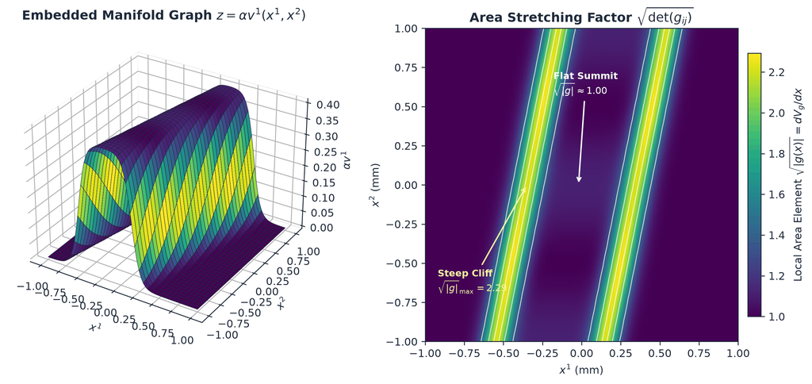

```python
from pathlib import Path
import numpy as np
import matplotlib.pyplot as plt
from matplotlib import cm
from matplotlib.colors import Normalize

Path("figures").mkdir(parents=True, exist_ok=True)
N = 75
x = np.linspace(-1.0, 1.0, N)
y = np.linspace(-1.0, 1.0, N)
X, Y = np.meshgrid(x, y, indexing="ij")
dx = x[1] - x[0]

ridge = 0.5 * (np.tanh(9.5 * (X + 0.35 - 0.2 * Y)) - np.tanh(9.5 * (X - 0.35 - 0.2 * Y)))
v1 = 0.90 * ridge
v2 = 0.35 * ridge * np.sin(np.pi * Y)

dv1_dx, dv1_dy = np.gradient(v1, dx, dx, edge_order=2)
dv2_dx, dv2_dy = np.gradient(v2, dx, dx, edge_order=2)

alpha = 0.45
g11 = 1.0 + alpha**2 * (dv1_dx**2 + dv2_dx**2)
g12 = alpha**2 * (dv1_dx * dv1_dy + dv2_dx * dv2_dy)
g22 = 1.0 + alpha**2 * (dv1_dy**2 + dv2_dy**2)
sqrt_g = np.sqrt(g11 * g22 - g12**2)
Z_graph = alpha * v1

fig = plt.figure(figsize=(11.4, 4.9))
ax3d = fig.add_subplot(1, 2, 1, projection="3d")
ax2d = fig.add_subplot(1, 2, 2)

norm = Normalize(vmin=1.0, vmax=sqrt_g.max())
facecolors = cm.viridis(norm(sqrt_g))

ax3d.plot_surface(
    X, Y, Z_graph, facecolors=facecolors, rstride=2, cstride=2,
    linewidth=0.35, edgecolor="#1e293b", antialiased=True, shade=False
)
ax3d.set_title("Embedded Manifold Graph $z = \\alpha v^1(x^1, x^2)$", fontweight="bold", pad=8)
ax3d.set_xlabel("$x^1$", labelpad=4)
ax3d.set_ylabel("$x^2$", labelpad=4)
ax3d.set_zlabel("$\\alpha v^1$", labelpad=3)
ax3d.view_init(elev=30, azim=-58)
ax3d.xaxis.pane.fill = False
ax3d.yaxis.pane.fill = False
ax3d.zaxis.pane.fill = False

im = ax2d.pcolormesh(X, Y, sqrt_g, cmap="viridis", norm=norm, shading="gouraud")
ax2d.contour(X, Y, Z_graph, levels=6, colors="#ffffff", linewidths=0.8, alpha=0.75)
ax2d.annotate(
    "Flat Summit\n$\\sqrt{|g|} \\approx 1.00$", xy=(-0.02, 0.0), xytext=(-0.18, 0.58),
    color="#ffffff", fontweight="bold", fontsize=8.8,
    arrowprops=dict(arrowstyle="->", color="#ffffff", lw=1.3)
)
ax2d.annotate(
    f"Steep Cliff\n$\\sqrt{{|g|}}_{{\\max}} = {sqrt_g.max():.2f}$", xy=(-0.35, 0.0), xytext=(-0.92, -0.68),
    color="#fef08a", fontweight="bold", fontsize=8.8,
    arrowprops=dict(arrowstyle="->", color="#fef08a", lw=1.3)
)
ax2d.set_title("Area Stretching Factor $\\sqrt{\\det(g_{ij})}$", fontweight="bold")
ax2d.set_xlabel("$x^1$ (mm)")
ax2d.set_ylabel("$x^2$ (mm)")
ax2d.set_aspect("equal")

cbar = fig.colorbar(im, ax=ax2d, shrink=0.84, pad=0.025)
cbar.set_label("Local Area Element $\\sqrt{|g(x)|} = dV_g / dx$")
plt.tight_layout()
fig.savefig("figures/fig_sec5_volume_element.png", dpi=160, bbox_inches="tight", facecolor="#ffffff")
plt.show()
```

**NoteGenerative 3D Illustration Prompt**

**Prompt:** Create a crisp 3D studio render on a pure white background (`#ffffff`) depicting a flexible, semi-transparent rubber sheet marked with an initially uniform square grid, draped tightly over a steep, narrow 3D ridge rising out of a flat plain. On the flat plains to the left and right and on the flat top crest of the ridge, the rubber grid squares remain compact, unstretched cyan squares of unit size. Along the steep vertical flanks of the ridge, the exact same grid cells stretch into tall, elongated glowing amber and gold rectangles, visually demonstrating local surface area expansion on steep manifold slopes. **CRITICAL CONSTRAINT: Include ZERO text, ZERO numbers, ZERO mathematical symbols, ZERO equations, and ZERO labels anywhere in the image.**

# 6 Term 4 — The Covariant Derivative ($\nabla_j v^k$) & Parallel Transport

## 6.1 Levi-Civita Connection & Curvilinear Basis Correction

On a general Riemannian manifold $(M, g)$ or oblique/curvilinear coordinate chart, tangent spaces $T_x M$ and $T_{x+\delta x} M$ are distinct vector spaces, and coordinate basis vectors $\{\partial_k\}$ rotate and stretch from point to point. Raw partial derivatives $\partial_j v^k$ measure component changes *relative to a moving frame*, failing to transform as a tensor.

The unique torsion-free ($\Gamma^k_{jl} = \Gamma^k_{lj}$), metric-compatible ($\nabla_m g_{kl} = 0$) **Levi-Civita connection** $\nabla$ compares neighboring vectors intrinsically by parallel-transporting $v(x)$ along $dx^j$ before differencing:

$$\nabla_j v^k(x) = \frac{\partial v^k(x)}{\partial x^j} + \sum_{l=1}^d \Gamma^k_{jl}(x) \, v^l(x),$$

where the **Christoffel symbols of the second kind** $\Gamma^k_{jl}(x)$ are fixed algebraically by first derivatives of the metric tensor:

$$\Gamma^k_{jl}(x) = \frac{1}{2} \sum_{m=1}^d g^{km}(x) \left( \frac{\partial g_{ml}(x)}{\partial x^j} + \frac{\partial g_{jm}(x)}{\partial x^l} - \frac{\partial g_{jl}(x)}{\partial x^m} \right).$$

Along a parameterized curve $\gamma : [0, 1] \to M$ with tangent $\dot{\gamma}^j(s) = \frac{d\gamma^j}{ds}$, $v$ undergoes **parallel transport** along $\gamma$ when its intrinsic directional derivative vanishes:

$$\frac{D v^k}{ds} \equiv \sum_{j=1}^d \dot{\gamma}^j(s) \, \nabla_j v^k\bigl(\gamma(s)\bigr)
= \frac{d v^k(\gamma(s))}{ds} + \sum_{j=1}^d \sum_{l=1}^d \Gamma^k_{jl}\bigl(\gamma(s)\bigr) \, \dot{\gamma}^j(s) \, v^l\bigl(\gamma(s)\bigr) = 0.$$

**ImportantCrucial Modeling Distinction: Intrinsic Section of TM vs. Extrinsic Cartesian Fiber Map**

The literature frequently conflates two distinct bundle choices in Beltrami PDEs; keeping them explicit avoids subtle discretization errors:

1. **Intrinsic Tangent Bundle Section ($v \in \Gamma(TM)$, $h_{kl} = g_{kl}$)**: Velocity components live directly in $TM$, so $\nabla_j v^k = \partial_j v^k + \Gamma^k_{jl} v^l$ carries the Christoffel connection on $TM$ (essential on cortical surfaces, spheres, or polar/cylindrical charts).
2. **Extrinsic Euclidean Fiber Map ($v : (M, g) \to (\mathbb{R}^d, \delta_{\alpha\beta})$)**: In Cartesian-grid Sochen–Kimmel–Malladi flow (and physical LPS displacement/velocity storage on affine grids where basis vectors are parallel across voxels), the target fiber $(\mathbb{R}^d, \delta_{\alpha\beta})$ is flat (${}^h\Gamma^\alpha_{\beta\gamma} = 0$), reducing the inner differential to $\nabla_j v^\alpha = \partial_j v^\alpha$ while retaining full manifold curvature through $g^{ij}(x)$ and $\sqrt{|g(x)|}$ in the outer divergence.

## 6.2 Term-by-Term Mathematical Dictionary

- $\partial_j v^k \equiv \frac{\partial v^k}{\partial x^j} : \Omega \to \mathbb{R}$: **Coordinate partial derivative** — Non-tensorial component slope ignoring basis variation $\nabla_{\partial_j}\partial_l$.
- $\nabla_j v^k : M \to T^*M \otimes TM$: **Levi-Civita covariant derivative** — Rank-$(1,1)$ tensor field measuring intrinsic vector variation after subtracting basis rotation/stretching.
- $\Gamma^k_{jl}(x)$: **Christoffel symbols of the second kind** — $d^3$ connection coefficients ($\Gamma^k_{jl} = \Gamma^k_{lj}$) satisfying $\nabla_{\partial_j} \partial_l = \sum_{k=1}^d \Gamma^k_{jl} \partial_k$.
- $l, m \in \{1, \dots, d\}$: **Contracted summation indices** — Dummy indices summed from $1$ to $d$.
- $TM$ and $\Gamma(TM)$: **Tangent bundle & smooth vector field space** — Vector bundle $\pi : TM \to M$ and space of smooth sections $v : M \to TM$.
- $\gamma : [0, 1] \to M$ and $\dot{\gamma}^j = d\gamma^j / ds$: **Smooth curve & curve velocity** — Trajectory in $M$ and its rank-$(1,0)$ tangent vector in $T_{\gamma(s)}M$.
- $\frac{Dv^k}{ds} = \dot{\gamma}^j \nabla_j v^k \in T_{\gamma(s)}M$: **Covariant derivative along $\gamma$** — Rate of deviation from parallel transport along $\gamma$.

## 6.3 Paired Numerical Verification & 3D Manifold Prompt

**Show deterministic Python verification & figure export code**

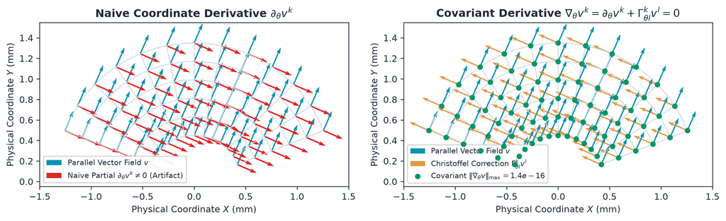

```python
from pathlib import Path
import numpy as np
import matplotlib.pyplot as plt

Path("figures").mkdir(parents=True, exist_ok=True)
nr, nth = 6, 13
r_vals = np.linspace(0.45, 1.35, nr)
th_vals = np.linspace(0.12 * np.pi, 0.88 * np.pi, nth)
R, TH = np.meshgrid(r_vals, th_vals, indexing="ij")

X = R * np.cos(TH)
Y = R * np.sin(TH)

Vx0, Vy0 = 0.35, 0.80
v_r =  Vx0 * np.cos(TH) + Vy0 * np.sin(TH)
v_th = (-Vx0 * np.sin(TH) + Vy0 * np.cos(TH)) / R

dv_r_dth_naive  = -Vx0 * np.sin(TH) + Vy0 * np.cos(TH)
dv_th_dth_naive = (-Vx0 * np.cos(TH) - Vy0 * np.sin(TH)) / R

chris_corr_r  = -R * v_th
chris_corr_th = (1.0 / R) * v_r

cov_r  = dv_r_dth_naive + chris_corr_r
cov_th = dv_th_dth_naive + chris_corr_th

def polar_to_cart(wr, wth):
    return wr * np.cos(TH) - R * wth * np.sin(TH), wr * np.sin(TH) + R * wth * np.cos(TH)

naive_x, naive_y = polar_to_cart(dv_r_dth_naive, dv_th_dth_naive)
chris_x, chris_y = polar_to_cart(chris_corr_r, chris_corr_th)
cov_x, cov_y     = polar_to_cart(cov_r, cov_th)

fig, (ax0, ax1) = plt.subplots(1, 2, figsize=(11.4, 4.8))

for ax in (ax0, ax1):
    th_fine = np.linspace(th_vals[0], th_vals[-1], 120)
    for i in range(nr):
        ax.plot(r_vals[i] * np.cos(th_fine), r_vals[i] * np.sin(th_fine), color="#cbd5e1", lw=0.9)
    for j in range(nth):
        ax.plot([r_vals[0] * np.cos(th_vals[j]), r_vals[-1] * np.cos(th_vals[j])],
                [r_vals[0] * np.sin(th_vals[j]), r_vals[-1] * np.sin(th_vals[j])], color="#cbd5e1", lw=0.9)
    ax.quiver(X, Y, np.full_like(X, Vx0), np.full_like(Y, Vy0),
              color="#0891b2", angles="xy", scale_units="xy", scale=4.2, width=0.0042,
              label="Parallel Vector Field $v$")
    ax.set_aspect("equal")
    ax.set_xlim(-1.5, 1.5)
    ax.set_ylim(-0.05, 1.55)
    ax.set_xlabel("Physical Coordinate $X$ (mm)")
    ax.set_ylabel("Physical Coordinate $Y$ (mm)")

ax0.quiver(X, Y, naive_x, naive_y, color="#dc2626", angles="xy", scale_units="xy", scale=4.2, width=0.0045,
           label="Naive Partial $\\partial_\\theta v^k \\neq 0$ (Artifact)")
ax0.set_title("Naive Coordinate Derivative $\\partial_\\theta v^k$", fontweight="bold")
ax0.legend(loc="lower left", facecolor="#ffffff", framealpha=0.94, fontsize=8.4)

ax1.quiver(X, Y, chris_x, chris_y, color="#d97706", angles="xy", scale_units="xy", scale=4.2, width=0.0040,
           alpha=0.75, label="Christoffel Correction $\\Gamma^k_{\\theta l} v^l$")
ax1.scatter(X, Y, color="#059669", s=26, zorder=6,
            label=f"Covariant $\\|\\nabla_\\theta v\\|_{{\\max}} = {np.hypot(cov_x, cov_y).max():.1e}$")
ax1.set_title("Covariant Derivative $\\nabla_\\theta v^k = \\partial_\\theta v^k + \\Gamma^k_{\\theta l} v^l = 0$",
              fontweight="bold")
ax1.legend(loc="lower left", facecolor="#ffffff", framealpha=0.94, fontsize=8.2)

plt.tight_layout()
fig.savefig("figures/fig_sec6_covariant_parallel_transport.png", dpi=160, bbox_inches="tight", facecolor="#ffffff")
plt.show()
```

**NoteGenerative 3D Illustration Prompt**

**Prompt:** Create a refined 3D differential geometry illustration on a pure white studio background (`#ffffff`) showing a smooth, glossy white curved dome (spherical manifold cap) traced by a glowing cyan geodesic arc connecting two distinct points on the surface. At both endpoints of the arc, render tilted, semi-transparent glass tangent planes resting flush against the dome. Show a sleek emerald 3D vector at the starting plane being transported along the geodesic arc to the destination plane: render two comparison vectors at the destination—one ghosted muted coral vector pointing straight out into ambient 3D space off the surface, and the true parallel-transported emerald vector tilted smoothly so it remains perfectly flush inside the destination tangent plane. **CRITICAL CONSTRAINT: Include ZERO text, ZERO numbers, ZERO mathematical symbols, ZERO equations, and ZERO labels anywhere in the image.**

# 7 From Energy to Operator — The Euler-Lagrange Derivation of $\Delta_g v$

## 7.1 Complete Variational Derivation via Manifold Divergence

We derive the **Beltrami operator** $\Delta_g v$ by computing the first variation of $E_{\text{Beltrami}}(v)$ in $L^2(M, dV_g)$. Let $v_\varepsilon^k(x) = v^k(x) + \varepsilon \eta^k(x)$ for $\varepsilon \in \mathbb{R}$ and arbitrary test velocity $\eta \in C_c^\infty(\Omega, \mathbb{R}^d)$ vanishing on $\partial\Omega$. Under the standard semi-implicit harmonic-map linearization (holding $g_{ij}$ fixed at the current iterate with Euclidean fiber metric $h_{kl} = \delta_{kl}$):

**Step 1 — Directional Gateaux Derivative at $\varepsilon = 0$:** Using symmetry $g^{ij} = g^{ji}$ to combine cross terms in $E_{\text{Beltrami}}(v + \varepsilon \eta) = \frac{1}{2}\int_\Omega g^{ij}\delta_{kl}(\nabla_i v^k + \varepsilon\nabla_i \eta^k)(\nabla_j v^l + \varepsilon\nabla_j \eta^l)\sqrt{|g|}\,dx$:

$$\delta E_{\text{Beltrami}}(v)[\eta]
\equiv \left. \frac{d}{d\varepsilon} E_{\text{Beltrami}}(v + \varepsilon \eta) \right|_{\varepsilon=0}
= \int_\Omega \sum_{i,j,k=1}^d \Bigl( \sqrt{|g(x)|} \, g^{ij}(x) \, \nabla_j v^k(x) \Bigr) \, \nabla_i \eta_k(x) \, dx.$$

**Step 2 — Leibniz Product Rule on the Flux Density:** For flat fiber coordinates ($\nabla_i \eta_k = \partial_i \eta_k$), expand the coordinate divergence of the scalar contraction $\mathcal{J}^i{}_k \eta^k$, where $\mathcal{J}^{ik} = \sqrt{|g|} g^{ij} \nabla_j v^k$:

$$\Bigl( \sqrt{|g|} \, g^{ij} \, \nabla_j v^k \Bigr) \partial_i \eta_k
= \partial_i \!\Bigl( \sqrt{|g|} \, g^{ij} (\nabla_j v^k) \, \eta_k \Bigr)
- \eta_k \, \partial_i \!\Bigl( \sqrt{|g|} \, g^{ij} \, \nabla_j v^k \Bigr).$$

**Step 3 — Gauss’s Divergence Theorem & Compact Support:** Integrating the total derivative over $\Omega$ converts it to a boundary flux integral over $\partial\Omega$ with outward normal $n_i$, which vanishes identically because $\operatorname{supp}(\eta) \Subset \Omega$:

$$\int_\Omega \sum_{i,k=1}^d \partial_i \!\Bigl( \sqrt{|g|} \, g^{ij} (\nabla_j v^k) \, \eta_k \Bigr) dx
= \oint_{\partial\Omega} \sum_{i,k=1}^d \sqrt{|g|} \, g^{ij} (\nabla_j v^k) \, \eta_k \, n_i \, dS = 0.$$

**Step 4 — Pairing in the Intrinsic $L^2(M, dV_g)$ Inner Product:** Multiplying and dividing the remaining integrand by $\sqrt{|g(x)|} > 0$ isolates the Riemannian volume element $dV_g = \sqrt{|g|}\,dx$:

$$\delta E_{\text{Beltrami}}(v)[\eta]
= -\int_\Omega \sum_{k=1}^d \eta_k(x) \left[ \frac{1}{\sqrt{|g(x)|}} \sum_{i=1}^d \partial_i \!\left( \sqrt{|g(x)|} \sum_{j=1}^d g^{ij}(x) \, \nabla_j v^k(x) \right) \right] \underbrace{\sqrt{|g(x)|} \, dx}_{dV_g}.$$

**Step 5 — Fundamental Lemma of the Calculus of Variations:** Since $\eta \in C_c^\infty(\Omega, \mathbb{R}^d)$ is arbitrary, $\frac{\delta E_{\text{Beltrami}}}{\delta v^k} = -(\Delta_g v)_k = 0$ at optimality, yielding the **Beltrami operator in divergence form**:

$$(\Delta_g v)^k = \frac{1}{\sqrt{|g|}} \, \partial_i \!\left( \sqrt{|g|} \, g^{ij} \, \nabla_j v^k \right), \qquad k \in \{1, \dots, d\}.$$

*(Technical remark: If $v \in \Gamma(TM)$ is varied with intrinsic covariant test fields on $TM$, replacing $\partial_i$ by covariant tensor divergence appends $+\Gamma^k_{im} g^{ij}\nabla_j v^m$. Conversely, under the Nambu–Goto area functional $\int \sqrt{|g(v)|}\,dx$ where $g_{ij}(v)$ is varied directly with respect to $\partial_i v^k$, differentiating $\sqrt{\det(I + \alpha^2 \nabla v^\top \nabla v)}$ produces the exact same divergence structure $\partial_i(\sqrt{|g|} g^{ij} \partial_j v^k)$ up to the scalar density factor $\sqrt{|g|}$.)*

## 7.2 Term-by-Term Pipeline Dictionary

- $\varepsilon \in \mathbb{R}, \; \eta^k \in C_c^\infty(\Omega)$: **Perturbation scalar & compactly supported virtual velocity** — Infinitesimal amplitude and test variation satisfying $\eta|_{\partial\Omega} = 0$.
- $\frac{\delta E_{\text{Beltrami}}}{\delta v^k} = -(\Delta_g v)_k$: **Intrinsic $L^2(M, dV_g)$ functional gradient** — Rank-$(0,1)$ variational derivative driving steepest descent $\partial_\tau v^k = (\Delta_g v)^k$.
- **Stage 1 — Inner Velocity Gradient** $F_j{}^k = \nabla_j v^k$: Rank-$(1,1)$ spatial derivative tensor capturing raw shear, compression, and noise.
- **Stage 2 — Contravariant Metric Projection** $P^{ik} = g^{ij} \nabla_j v^k$: Rank-$(2,0)$ projected gradient attenuating flux across high-strain shear boundaries ($\mu_1 \ll 1$).
- **Stage 3 — Area-Weighted Flux Density** $\mathcal{J}^{ik} = \sqrt{|g|} \, g^{ij} \, \nabla_j v^k$: Tensor density of weight $+1$ scaling diffusive transport by manifold area element $\sqrt{|g|}$.
- **Stage 4 — Normalized Flux Divergence** $(\Delta_g v)^k = \frac{1}{\sqrt{|g|}} \partial_i \mathcal{J}^{ik}$: Net restoring force vector relaxing local oscillations back toward the manifold harmonic equilibrium.

## 7.3 Paired Numerical Verification & 3D Manifold Prompt

**Show deterministic Python verification & figure export code**

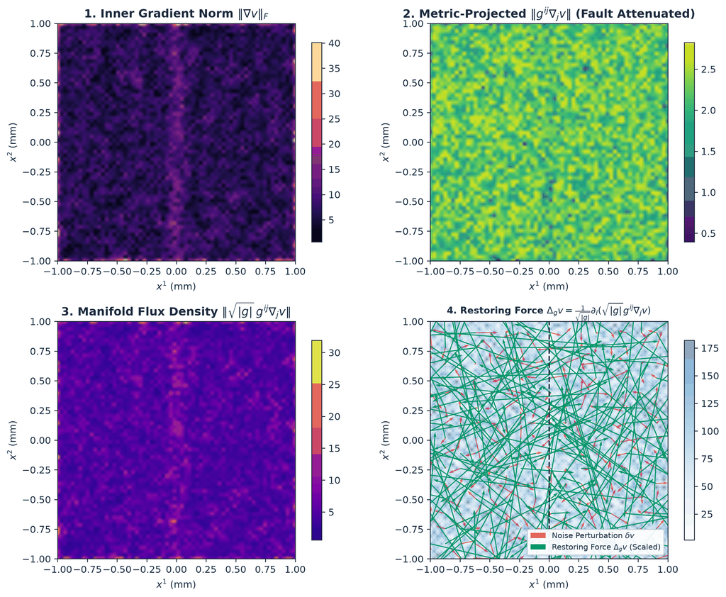

Figure 7: Four-stage internal decomposition of (Δ_g v)^k on a noisy shear fault: (1) raw Frobenius gradient ||∇v||_F, (2) inverse-metric projection ||g^{ij}∇_j v|| suppressing cross-fault gradient spikes, (3) area-scaled flux ||√|g| g^{ij}∇_j v||, and (4) net Beltrami restoring force Δ_g v opposing noise perturbations δv without blurring the central shear plane.

```python
from pathlib import Path
import numpy as np
import matplotlib.pyplot as plt

Path("figures").mkdir(parents=True, exist_ok=True)
rng = np.random.default_rng(7)
N = 64
x = np.linspace(-1.0, 1.0, N)
y = np.linspace(-1.0, 1.0, N)
X, Y = np.meshgrid(x, y, indexing="ij")
dx = x[1] - x[0]

v1_clean = 0.08 * np.sin(np.pi * Y)
v2_clean = 0.80 * np.tanh(14.0 * X)
noise_x = 0.16 * rng.standard_normal((N, N))
noise_y = 0.16 * rng.standard_normal((N, N))
v1 = v1_clean + noise_x
v2 = v2_clean + noise_y

dv1_dx, dv1_dy = np.gradient(v1, dx, dx, edge_order=2)
dv2_dx, dv2_dy = np.gradient(v2, dx, dx, edge_order=2)
grad_mag = np.sqrt(dv1_dx**2 + dv1_dy**2 + dv2_dx**2 + dv2_dy**2)

alpha = 0.25
g11 = 1.0 + alpha**2 * (dv1_dx**2 + dv2_dx**2)
g12 = alpha**2 * (dv1_dx * dv1_dy + dv2_dx * dv2_dy)
g22 = 1.0 + alpha**2 * (dv1_dy**2 + dv2_dy**2)
det_g = g11 * g22 - g12**2
sqrt_g = np.sqrt(det_g)
ginv11, ginv12, ginv22 = g22 / det_g, -g12 / det_g, g11 / det_g

P1_v1 = ginv11 * dv1_dx + ginv12 * dv1_dy
P2_v1 = ginv12 * dv1_dx + ginv22 * dv1_dy
P1_v2 = ginv11 * dv2_dx + ginv12 * dv2_dy
P2_v2 = ginv12 * dv2_dx + ginv22 * dv2_dy
proj_mag = np.sqrt(P1_v1**2 + P2_v1**2 + P1_v2**2 + P2_v2**2)

J1_v1, J2_v1 = sqrt_g * P1_v1, sqrt_g * P2_v1
J1_v2, J2_v2 = sqrt_g * P1_v2, sqrt_g * P2_v2
flux_mag = np.sqrt(J1_v1**2 + J2_v1**2 + J1_v2**2 + J2_v2**2)

div_J_v1 = np.gradient(J1_v1, dx, axis=0, edge_order=2) + np.gradient(J2_v1, dx, axis=1, edge_order=2)
div_J_v2 = np.gradient(J1_v2, dx, axis=0, edge_order=2) + np.gradient(J2_v2, dx, axis=1, edge_order=2)
beltrami_v1, beltrami_v2 = div_J_v1 / sqrt_g, div_J_v2 / sqrt_g
force_mag = np.hypot(beltrami_v1, beltrami_v2)

fig, axes = plt.subplots(2, 2, figsize=(11.2, 8.8))

im0 = axes[0, 0].pcolormesh(X, Y, grad_mag, cmap="magma", shading="gouraud")
axes[0, 0].set_title("1. Inner Gradient Norm $\\|\\nabla v\\|_F$", fontweight="bold")
fig.colorbar(im0, ax=axes[0, 0], shrink=0.84)

im1 = axes[0, 1].pcolormesh(X, Y, proj_mag, cmap="viridis", shading="gouraud")
axes[0, 1].set_title("2. Metric-Projected $\\|g^{ij}\\nabla_j v\\|$ (Fault Attenuated)", fontweight="bold")
fig.colorbar(im1, ax=axes[0, 1], shrink=0.84)

im2 = axes[1, 0].pcolormesh(X, Y, flux_mag, cmap="plasma", shading="gouraud")
axes[1, 0].set_title("3. Manifold Flux Density $\\|\\sqrt{|g|}\\,g^{ij}\\nabla_j v\\|$", fontweight="bold")
fig.colorbar(im2, ax=axes[1, 0], shrink=0.84)

im3 = axes[1, 1].pcolormesh(X, Y, np.clip(force_mag, 0, np.percentile(force_mag, 97)),
                            cmap="Blues", alpha=0.45, shading="gouraud")
s = 4
axes[1, 1].quiver(
    X[::s, ::s], Y[::s, ::s], noise_x[::s, ::s], noise_y[::s, ::s],
    color="#dc2626", angles="xy", scale_units="xy", scale=2.2, width=0.0038, alpha=0.75,
    label="Noise Perturbation $\\delta v$"
)
axes[1, 1].quiver(
    X[::s, ::s], Y[::s, ::s], beltrami_v1[::s, ::s], beltrami_v2[::s, ::s],
    color="#059669", angles="xy", scale_units="xy", scale=95.0, width=0.0042,
    label="Restoring Force $\\Delta_g v$ (Scaled)"
)
axes[1, 1].axvline(0.0, color="#1e293b", ls="--", lw=1.4)
axes[1, 1].set_title("4. Restoring Force $\\Delta_g v = \\frac{1}{\\sqrt{|g|}}\\partial_i(\\sqrt{|g|}g^{ij}\\nabla_j v)$",
                     fontweight="bold", fontsize=9.8)
axes[1, 1].legend(loc="lower right", facecolor="#ffffff", framealpha=0.92, fontsize=8.0)
fig.colorbar(im3, ax=axes[1, 1], shrink=0.84)

for ax in axes.ravel():
    ax.set_xlabel("$x^1$ (mm)")
    ax.set_ylabel("$x^2$ (mm)")
    ax.set_aspect("equal")

plt.tight_layout()
fig.savefig("figures/fig_sec7_operator_pipeline.png", dpi=160, bbox_inches="tight", facecolor="#ffffff")
plt.show()
```

**NoteGenerative 3D Illustration Prompt**

**Prompt:** Create a sleek 3D vector-field force illustration set against a pure white studio background (`#ffffff`). Over a gently curving alabaster manifold surface, render a smooth S-shaped river of cyan 3D velocity arrows flowing in unison, interrupted at several scattered spots by erratic, jagged slate-dark arrows jutting sharply upward and sideways out of alignment. Attached to the tip of every jagged outlier arrow, render a luminous glowing emerald restoring-force arrow pulling the tip firmly downward and inward back toward the smooth local neighborhood streamline average, visually depicting variational tension relaxing jagged vectors without disturbing the smooth river edge. **CRITICAL CONSTRAINT: Include ZERO text, ZERO numbers, ZERO mathematical symbols, ZERO equations, and ZERO labels anywhere in the image.**

# 8 What Does It Penalize? (Decomposition, Physical Modes & `syntx` Realization)

## 8.2 Term-by-Term Mathematical Dictionary

- $\Delta_{\text{Euc}} : C^\infty(\Omega, \mathbb{R}^d) \to C^\infty(\Omega, \mathbb{R}^d)$: **Euclidean vector Laplacian** — Isotropic second-order operator $\sum_{i=1}^d \partial_i^2 v^k$.
- $\mu \in \mathbb{R}_{>0}, \; \lambda \in \mathbb{R}$: **Lamé continuum moduli** — Shear viscosity ($\mu$) and volumetric dilatation parameter ($\lambda$).
- $D(v)_{ij} = \frac{1}{2}(\nabla_i v_j + \nabla_j v_i)$ and $D_{\text{conf}}(v)_{ij}$: **Strain-rate & conformal Killing tensors** — Rank-$(0,2)$ symmetric strain rate and its trace-free deviatoric projection measuring angle/aspect-ratio distortion.
- $v^\flat = g_{ij} v^i dx^j \in \Omega^1(M)$: **Metric-dual 1-form** — Covector field obtained by index lowering.
- $d : \Omega^p(M) \to \Omega^{p+1}(M)$ and $d^* : \Omega^{p+1}(M) \to \Omega^p(M)$: **Exterior derivative & codifferential** — Differential form coboundary operator and its $L^2(M, dV_g)$ formal adjoint.
- $\Delta_H = d d^* + d^* d : \Omega^1(M) \to \Omega^1(M)$: **Hodge–de Rham Laplacian** — Intrinsic elliptic operator penalizing $\operatorname{div}_g(v)$ and vorticity $dv^\flat$.
- $\operatorname{div}_g(v) : M \to \mathbb{R}$ and $\operatorname{curl}(v) \equiv dv^\flat \in \Omega^2(M)$: **Riemannian divergence & vorticity 2-form** — Volumetric expansion rate $\frac{1}{\sqrt{|g|}}\partial_i(\sqrt{|g|}v^i)$ and antisymmetric spin $\nabla_i v_j - \nabla_j v_i$.
- $\nabla^* \nabla : \Gamma(TM) \to \Gamma(TM)$: **Bochner connection Laplacian** — Rough Laplacian $-g^{ij}\nabla_i\nabla_j$ dual to $\int_M \|\nabla v\|_g^2 dV_g$.
- $\operatorname{Ric}_{ml} = R^p{}_{mpl}$ and $\operatorname{Ric}_g(v)^k = g^{km} R_{ml} v^l$: **Ricci curvature tensor & endomorphism** — Rank-$(0,2)$ trace of Riemann curvature and its rank-$(1,1)$ action in the Bochner–Weitzenböck formula.
- $\widehat{G}_{\text{Beltrami}}(k) \in \mathbb{R}^{d \times d}$: **Spectral quasiconformal Beltrami Green’s kernel** — Rank-$(1,1)$ Fourier multiplier at relative-aspect-ratio wave vector $k \in \mathbb{R}^d$ with Sobolev order $s > 0$.

## 8.3 Paired Numerical Verification & 3D Manifold Prompt

**Show deterministic Python verification & figure export code**

[figure not shown]

```python
from pathlib import Path
import numpy as np
import matplotlib.pyplot as plt

Path("figures").mkdir(parents=True, exist_ok=True)
rng = np.random.default_rng(108)
N = 56
x = np.linspace(-1.0, 1.0, N)
y = np.linspace(-1.0, 1.0, N)
X, Y = np.meshgrid(x, y, indexing="ij")
dx = x[1] - x[0]

def beltrami_flow(v1_init, v2_init, alpha=0.32, dt=0.0018, n_steps=55):
    u1, u2 = v1_init.copy(), v2_init.copy()
    for _ in range(n_steps):
        du1_x, du1_y = np.gradient(u1, dx, dx, edge_order=2)
        du2_x, du2_y = np.gradient(u2, dx, dx, edge_order=2)
        g11 = 1.0 + alpha**2 * (du1_x**2 + du2_x**2)
        g12 = alpha**2 * (du1_x * du1_y + du2_x * du2_y)
        g22 = 1.0 + alpha**2 * (du1_y**2 + du2_y**2)
        det_g = g11 * g22 - g12**2
        sg = np.sqrt(det_g)
        gi11, gi12, gi22 = g22 / det_g, -g12 / det_g, g11 / det_g

        J1_1 = sg * (gi11 * du1_x + gi12 * du1_y)
        J2_1 = sg * (gi12 * du1_x + gi22 * du1_y)
        J1_2 = sg * (gi11 * du2_x + gi12 * du2_y)
        J2_2 = sg * (gi12 * du2_x + gi22 * du2_y)

        u1 += dt * (np.gradient(J1_1, dx, axis=0) + np.gradient(J2_1, dx, axis=1)) / sg
        u2 += dt * (np.gradient(J1_2, dx, axis=0) + np.gradient(J2_2, dx, axis=1)) / sg
    return u1, u2

def euclidean_flow(v1_init, v2_init, dt=0.0018, n_steps=55):
    u1, u2 = v1_init.copy(), v2_init.copy()
    for _ in range(n_steps):
        for arr in (u1, u2):
            gx, gy = np.gradient(arr, dx, dx)
            arr += dt * (np.gradient(gx, dx, axis=0) + np.gradient(gy, dx, axis=1))
    return u1, u2

r2 = X**2 + Y**2
sink_env = np.exp(-16.0 * r2)
m1_v1_0 = -1.35 * X * sink_env + 0.08 * rng.standard_normal((N, N))
m1_v2_0 = -1.35 * Y * sink_env + 0.08 * rng.standard_normal((N, N))
m1_v1_f, m1_v2_f = beltrami_flow(m1_v1_0, m1_v2_0, alpha=0.12, n_steps=50)

m2_v1_0 = 0.14 * rng.standard_normal((N, N))
m2_v2_0 = 0.85 * np.sign(X) * (1.0 - np.exp(-25.0 * np.abs(X))) + 0.14 * rng.standard_normal((N, N))
m2_v1_f, m2_v2_f = beltrami_flow(m2_v1_0, m2_v2_0, alpha=0.42, n_steps=65)
_, m2_v2_euc = euclidean_flow(m2_v1_0, m2_v2_0, n_steps=65)

m3_v1_0 = 0.40 + 0.36 * rng.standard_normal((N, N))
m3_v2_0 = 0.25 * np.sin(np.pi * X) + 0.36 * rng.standard_normal((N, N))
m3_v1_f, m3_v2_f = beltrami_flow(m3_v1_0, m3_v2_0, alpha=0.20, n_steps=60)

fig, axes = plt.subplots(3, 2, figsize=(11.2, 11.6))
s = 4

div_0 = np.gradient(m1_v1_0, dx, axis=0) + np.gradient(m1_v2_0, dx, axis=1)
div_f = np.gradient(m1_v1_f, dx, axis=0) + np.gradient(m1_v2_f, dx, axis=1)
for ax, u1, u2, div_field, tag in [
    (axes[0, 0], m1_v1_0, m1_v2_0, div_0, f"Before: Singular Sink (min $\\nabla\\cdot v = {div_0.min():.1f}$)"),
    (axes[0, 1], m1_v1_f, m1_v2_f, div_f, f"After Beltrami: Relaxed Sink (min $\\nabla\\cdot v = {div_f.min():.1f}$)"),
]:
    im = ax.pcolormesh(X, Y, div_field, cmap="RdBu_r", vmin=-3.2, vmax=3.2, shading="gouraud", alpha=0.75)
    ax.quiver(X[::s, ::s], Y[::s, ::s], u1[::s, ::s], u2[::s, ::s],
              color="#1e293b", angles="xy", scale_units="xy", scale=3.2, width=0.004)
    ax.set_title(f"Mode 1 (Compression) — {tag}", fontweight="bold", fontsize=9.6)
    fig.colorbar(im, ax=ax, shrink=0.82, label="$\\nabla \\cdot v$")

for ax, u1, u2, tag in [
    (axes[1, 0], m2_v1_0, m2_v2_0, "Before: Noisy Sliding Shear Fault"),
    (axes[1, 1], m2_v1_f, m2_v2_f, "After Beltrami: Denoised + Sharp Step Preserved"),
]:
    im = ax.pcolormesh(X, Y, u2, cmap="coolwarm", vmin=-1.0, vmax=1.0, shading="gouraud", alpha=0.55)
    ax.quiver(X[::s, ::s], Y[::s, ::s], u1[::s, ::s], u2[::s, ::s],
              color="#1e293b", angles="xy", scale_units="xy", scale=5.5, width=0.0038)
    ax.axvline(0.0, color="#1e293b", ls="--", lw=1.3)
    ax.set_title(f"Mode 2 (Shear Edge) — {tag}", fontweight="bold", fontsize=9.6)
    fig.colorbar(im, ax=ax, shrink=0.82, label="Shear $v^2$")

mid = N // 2
ax_in = axes[1, 1].inset_axes([0.52, 0.08, 0.44, 0.34])
ax_in.plot(x, m2_v2_f[:, mid], color="#059669", lw=2.0, label="Beltrami")
ax_in.plot(x, m2_v2_euc[:, mid], "--", color="#dc2626", lw=1.8, label="Euclidean $\\Delta$")
ax_in.set_facecolor("#ffffff")
ax_in.tick_params(labelsize=6.5)
ax_in.set_title("Fault Profile $v^2(x^1,0)$", fontsize=7.2, fontweight="bold")
ax_in.legend(fontsize=6.3, loc="upper left", frameon=False)

curl_0 = np.gradient(m3_v2_0, dx, axis=0) - np.gradient(m3_v1_0, dx, axis=1)
curl_f = np.gradient(m3_v2_f, dx, axis=0) - np.gradient(m3_v1_f, dx, axis=1)
for ax, u1, u2, c_field, tag in [
    (axes[2, 0], m3_v1_0, m3_v2_0, curl_0, f"Before: Jitter ($\\|\\nabla\\times v\\|_{{RMS}} = {np.sqrt(np.mean(curl_0**2)):.2f}$)"),
    (axes[2, 1], m3_v1_f, m3_v2_f, curl_f, f"After Beltrami: Coherent ($\\|\\nabla\\times v\\|_{{RMS}} = {np.sqrt(np.mean(curl_f**2)):.2f}$)"),
]:
    im = ax.pcolormesh(X, Y, c_field, cmap="PuOr", vmin=-8.0, vmax=8.0, shading="gouraud", alpha=0.65)
    ax.quiver(X[::s, ::s], Y[::s, ::s], u1[::s, ::s], u2[::s, ::s],
              color="#1e293b", angles="xy", scale_units="xy", scale=4.8, width=0.004)
    ax.set_title(f"Mode 3 (High-Freq Jitter) — {tag}", fontweight="bold", fontsize=9.6)
    fig.colorbar(im, ax=ax, shrink=0.82, label="Vorticity $\\nabla \\times v$")

for ax in axes.ravel():
    ax.set_xlabel("$x^1$ (mm)")
    ax.set_ylabel("$x^2$ (mm)")
    ax.set_aspect("equal")

plt.tight_layout()
fig.savefig("figures/fig_sec8_three_modes_grid.png", dpi=160, bbox_inches="tight", facecolor="#ffffff")
plt.show()
```

**NoteGenerative 3D Illustration Prompt**

**Prompt:** Create a triptych of three crystal-clear 3D glass fluid cubes arranged side by side on a pure white studio floor (`#ffffff`), each transitioning smoothly from front-to-back to show regularization in action. In the left cube, show inward-crushing crimson arrows imploding toward a dense focal core in the front half, relaxing into gentle, evenly spaced cyan streamlines in the back half. In the center cube, show two opposing fluid currents sliding cleanly past a razor-sharp vertical glass fault plane, with noisy ripples calming into smooth parallel emerald ribbons without crossing the central plane. In the right cube, show chaotic, buzzing multi-directional amber arrows in the front half calming into serene, parallel sapphire streamlines in the back half. **CRITICAL CONSTRAINT: Include ZERO text, ZERO numbers, ZERO mathematical symbols, ZERO equations, and ZERO labels anywhere in the image.**

## 8.4 References

1. **Beg, M. F., Miller, M. I., Trouvé, A., & Younes, L.** (2005). Computing large deformation metric mappings via geodesic flows of diffeomorphisms. *International Journal of Computer Vision*, 61(2), 139–157.
2. **Avants, B. B., Epstein, C. L., Grossman, M., & Gee, J. C.** (2008). Symmetric diffeomorphic image registration with cross-correlation: Evaluating automated labeling of elderly and neurodegenerative brain. *Medical Image Analysis*, 12(1), 26–41.
3. **Sochen, N., Kimmel, R., & Malladi, R.** (1998). A general framework for low level vision. *IEEE Transactions on Image Processing*, 7(3), 310–318.
4. **Eells, J., & Sampson, J. H.** (1964). Harmonic mappings of Riemannian manifolds. *American Journal of Mathematics*, 86(1), 109–160.